# Research Data Consultations

## Introduction

Research data consultations are booked in 1 hour blocks. Students are encouraged to return throughout project development, including during planning, collection, cleaning and analysis, and presentation. To help maintain a focus on learning, students deposit data on UBC’s OneDrive, where consultants, when possible, help with demonstration code on only a subset of the deposited data.

UBCO Biology funding started September, 2024, with 1 TA position in W1 and 2 TA positions in W2.

## Feedback

- “The explanation of new ideas and resources to help me with my research [was helpful].”
- “[The consultant] modeled how to do the next steps and ensured I understood before the end of the session. [They] seemed committed to helping find the best solutions for my struggles.”
- “[Learning] [h]ow to treat sparse data [was helpful].”
- “Talking through the steps of reporting a model-based analysis…it was very good, couldn’t have been better.”
- “[The consultant] helped me to think about my research from other directions and consider how to best analyze the data before any is even collected. [They] really encouraged me to think through all the potential effects on my study system so that I don’t look back and wish I had collected data on a certain variable. I have begun to make a causal flowchart like [they] suggested, which is really helping me.”
- “[The consultant] explained to me what type of model to use, why we use it and how to use it. It helped me understand my data and conclude something.”
- “[The consultant] gave a suggestion on what kind of plot is best how to visualize my data.”

## Distribution by Time

### September 2024 - Present

#### Non unique users

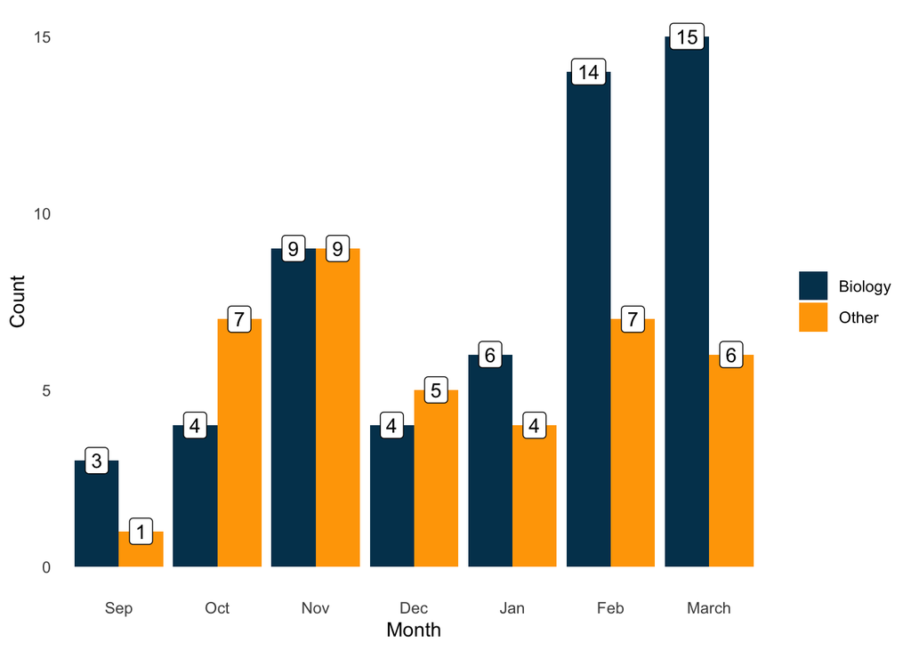

#### Unique users

Unique users by month. A user may still be replicated across months.

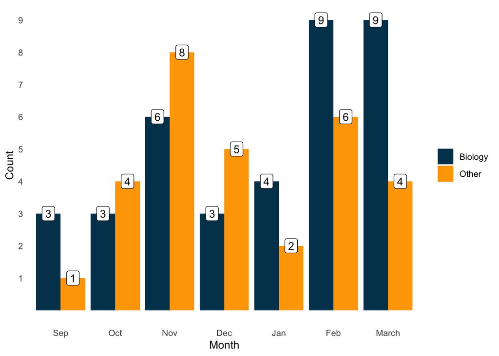

## Distribution by Program

### September 2024 - Present

#### Unique users

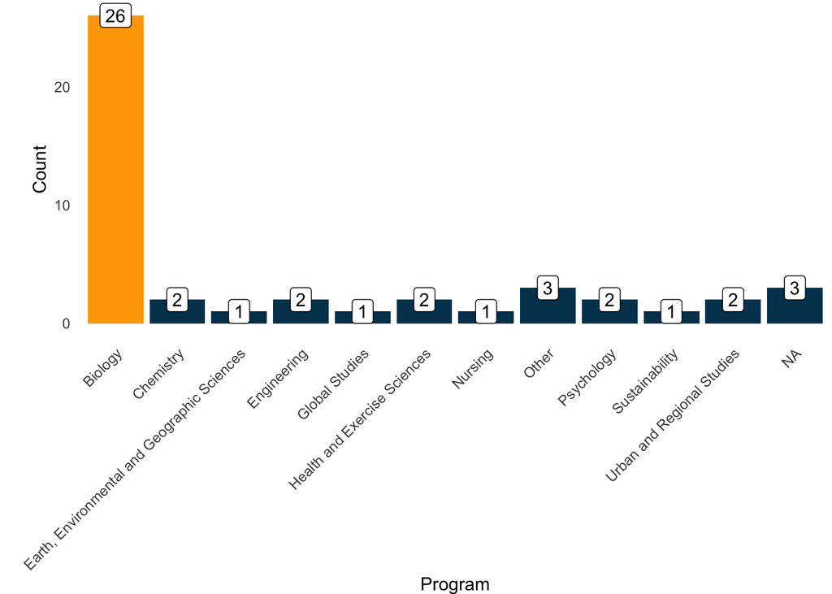

### January 2023 - Present

#### Unique users

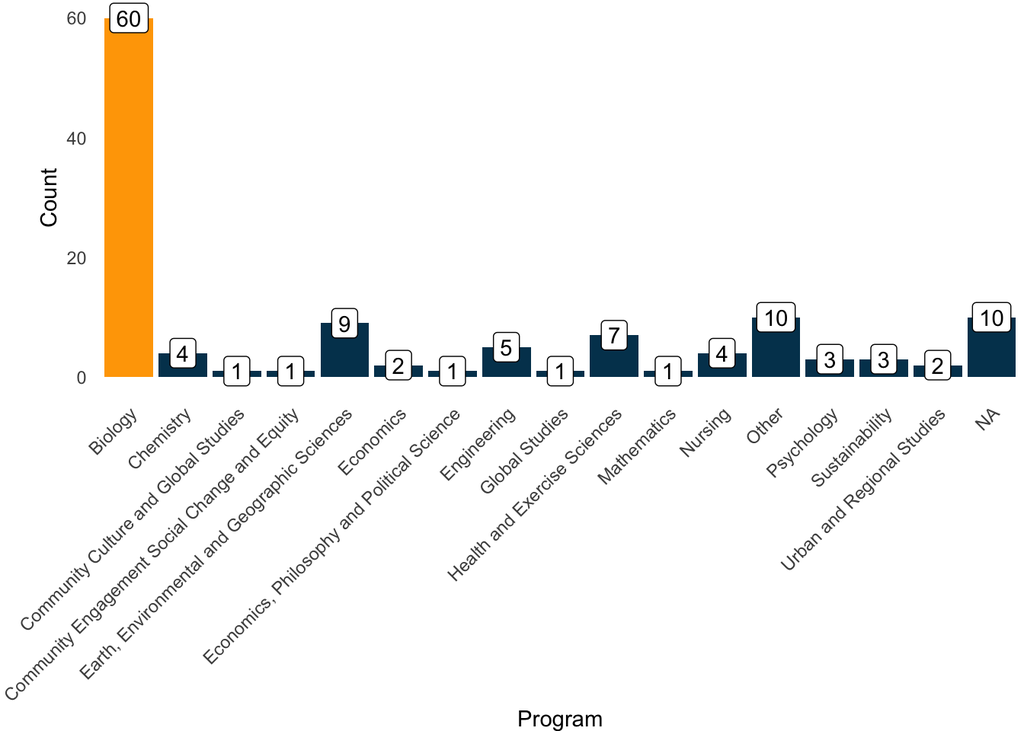

## Distribution by Degree

### January 2023 - Present

#### Unique Users

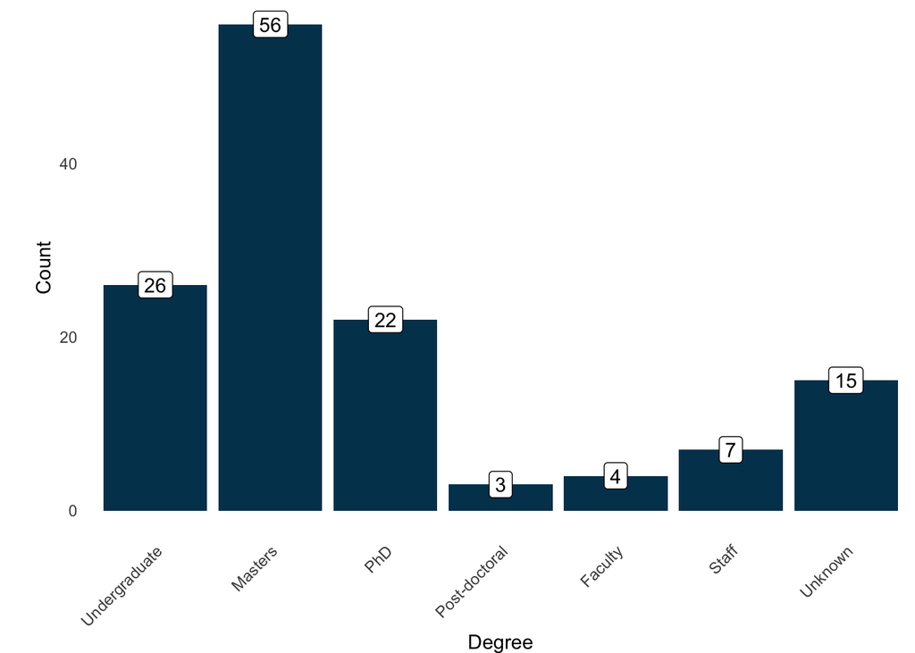

## Program Summary Tables

### September 2024 - March 2025

#### Non unique users

**Total = 94**

| Program | Count |
| --- | --- |
| Biology | 55 |
| NA | 9 |
| Urban and Regional Studies | 7 |
| Earth, Environmental and Geographic Sciences | 4 |
| Nursing | 4 |
| Other | 3 |
| Psychology | 3 |
| Chemistry | 2 |
| Engineering | 2 |
| Health and Exercise Sciences | 2 |
| Sustainability | 2 |
| Global Studies | 1 |

#### Unique users

**Total = 46**

| Program | Count |
| --- | --- |
| Biology | 26 |
| Other | 3 |
| NA | 3 |
| Chemistry | 2 |
| Engineering | 2 |
| Health and Exercise Sciences | 2 |
| Psychology | 2 |
| Urban and Regional Studies | 2 |
| Earth, Environmental and Geographic Sciences | 1 |
| Global Studies | 1 |
| Nursing | 1 |
| Sustainability | 1 |

### January 2023 - March 2025

#### Non unique users

**Total = 391**

| Program | Count |
| --- | --- |
| Biology | 259 |
| Earth, Environmental and Geographic Sciences | 18 |
| Other | 18 |
| NA | 17 |
| Health and Exercise Sciences | 12 |
| Psychology | 11 |
| Economics | 10 |
| Nursing | 9 |
| Economics, Philosophy and Political Science | 8 |
| Engineering | 7 |
| Urban and Regional Studies | 7 |
| Chemistry | 4 |
| Community Culture and Global Studies | 4 |
| Sustainability | 4 |
| Community Engagement Social Change and Equity | 1 |
| Global Studies | 1 |
| Mathematics | 1 |

#### Unique users

**Total = 124**

| Program | Count |
| --- | --- |
| Biology | 60 |
| Other | 10 |
| NA | 10 |
| Earth, Environmental and Geographic Sciences | 9 |
| Health and Exercise Sciences | 7 |
| Engineering | 5 |
| Chemistry | 4 |
| Nursing | 4 |
| Psychology | 3 |
| Sustainability | 3 |
| Economics | 2 |
| Urban and Regional Studies | 2 |
| Community Culture and Global Studies | 1 |
| Community Engagement Social Change and Equity | 1 |
| Economics, Philosophy and Political Science | 1 |
| Global Studies | 1 |
| Mathematics | 1 |